# Exploratory Data Analysis of Kickstarter Data

# Description

I found this dataset on kaggle.com and thought it would be interesting to use for Udacity’s Exploratory Data Analysis project.

The set contains the first 4000 Kickstarter projects that were available on Oct. 29, 2016.

# Univariate Plots Section

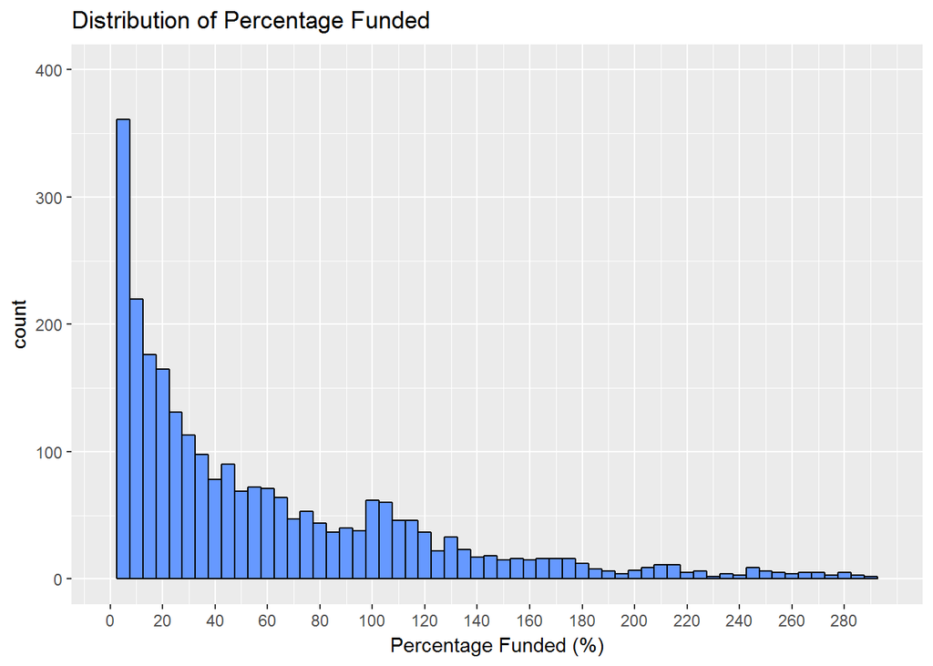

```
##     Min.  1st Qu.   Median     Mean  3rd Qu.     Max.
##     0.00     1.00    18.00    97.16    74.00 28000.00
```

I first want to look at how many of our 4,000 projects have met or exceeded their funding goals so I plotted a histogram of our percentage funded variable, a variable that explains what percentage the project is funded in relation to its fundraising goals (ex: If I need $100 to print a cool sticker design and users have pledged $50, I am 50% funded)

As we can see, the mode occurs somewhere in our 0-5% bucket and the median funded project is 18%. The average is much higher because we have extremely skewed data due to some projects vastly exceeding 100% funding.

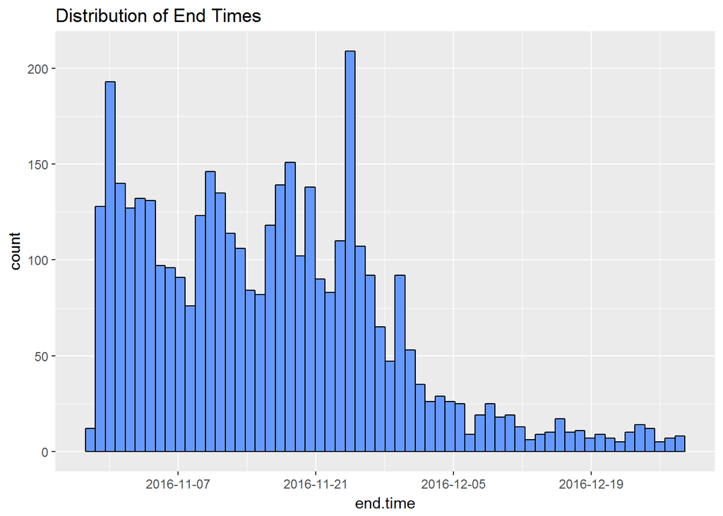

Of these 4,000 live projects, how long will they be available on Kickstarter? To answer this, I took a look at the end.time variable which has the date the project will be removed from Kickstarter. It looks like at this given time, projects end within the next month (this data was pulled on Oct. 29th). I wonder if the approaching holiday season had any influence here…

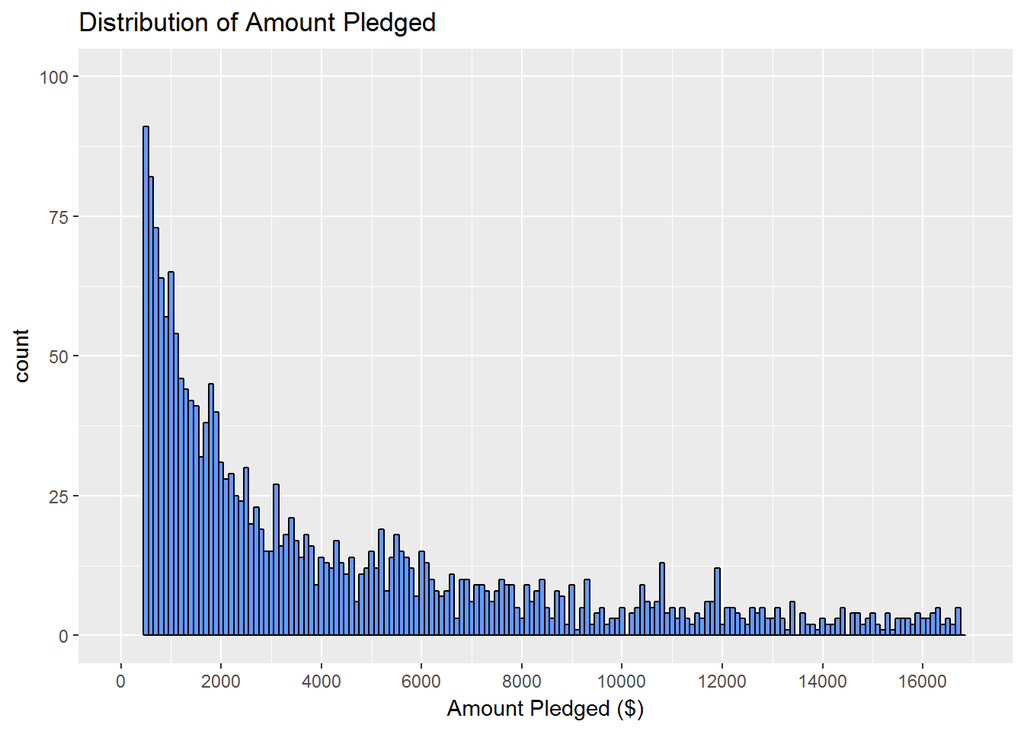

```
##    Min. 1st Qu.  Median    Mean 3rd Qu.    Max.
##       0     100    1036   10230    5450 1828000
```

I was wondering how much funding these projects typically get so I plotted a histogram of amounts pledged, the total amount of funding the project has at a given time. It looks like if you only need $1,000 to get your idea started, Kickstarter might be an appropriate platform.

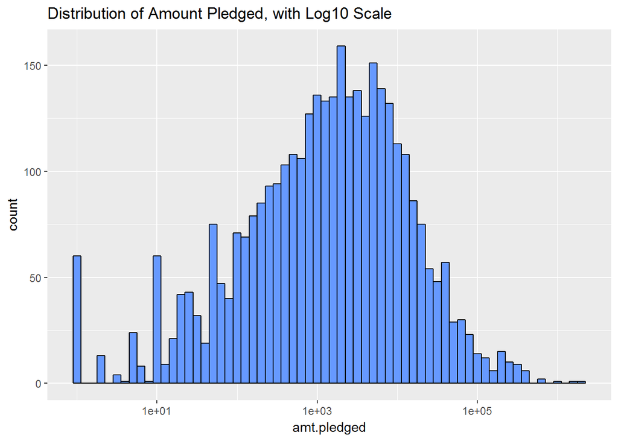

```
##    Min. 1st Qu.  Median    Mean 3rd Qu.    Max.
##       0     100    1036   10230    5450 1828000
```

Since the skew was so extreme on the last plot (I limited our x axis quite a bit) I thought I would adjust the axis by log10 to get a better look at our distribution.

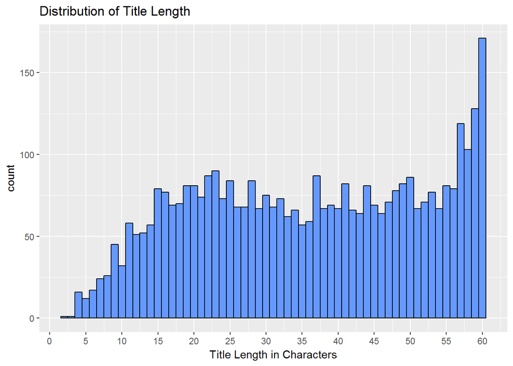

```
##    Min. 1st Qu.  Median    Mean 3rd Qu.    Max.
##    2.00   22.00   36.00   35.94   50.00   60.00
```

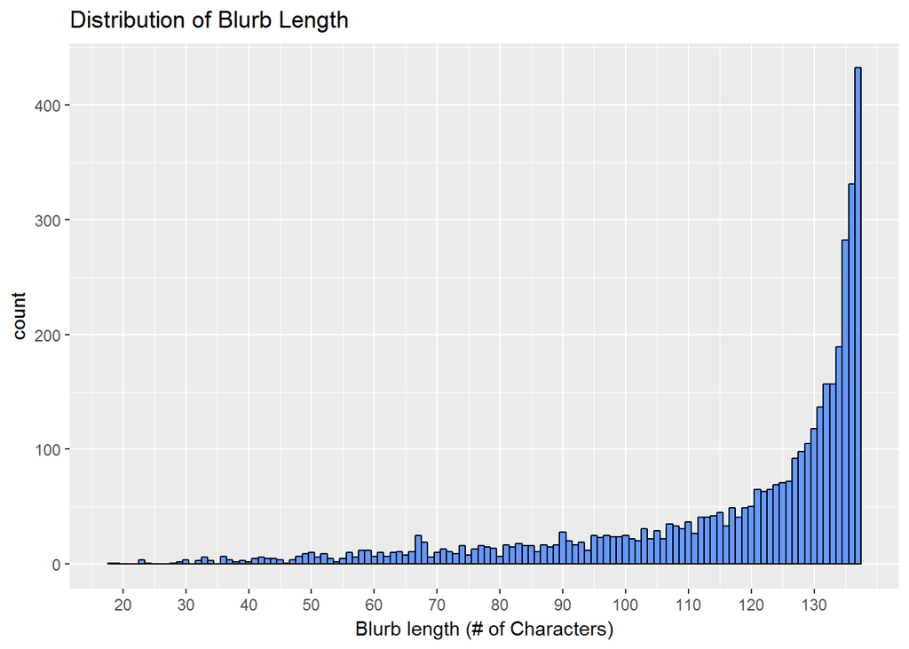

While users may not use their entire title field, they are certainly taking advantage of the blurb! As we can see here, short blurbs are not very common.

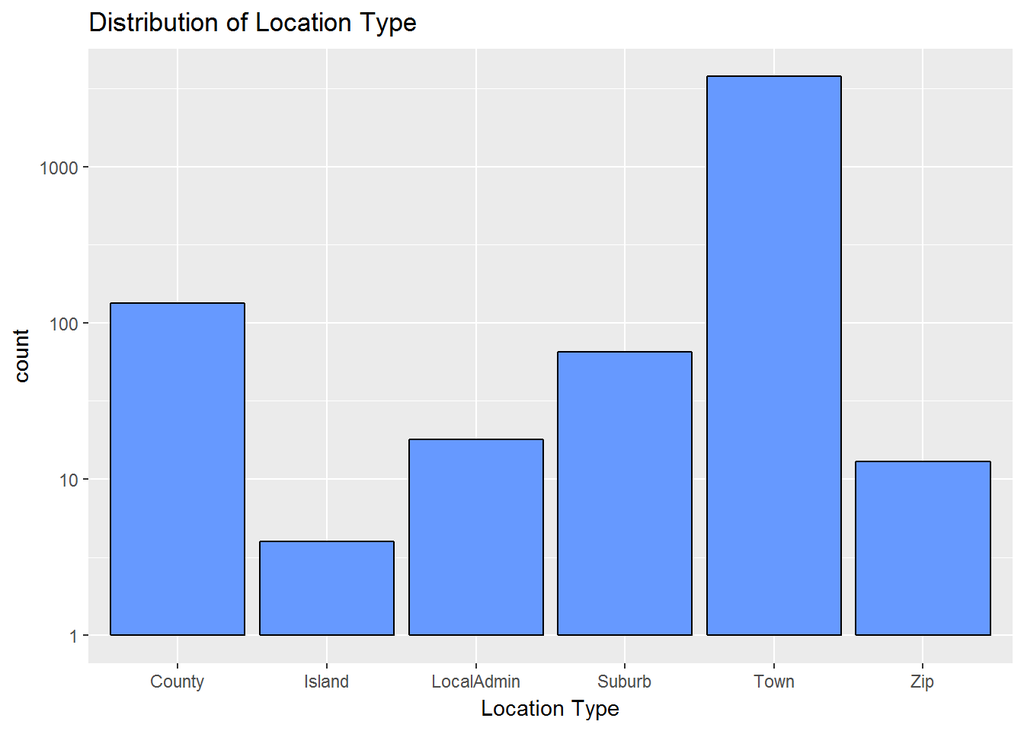

The distibution of locations was strongly in favor of the ‘Town’ value, again I had to use logarithmic scaling to represent the huge range of values.

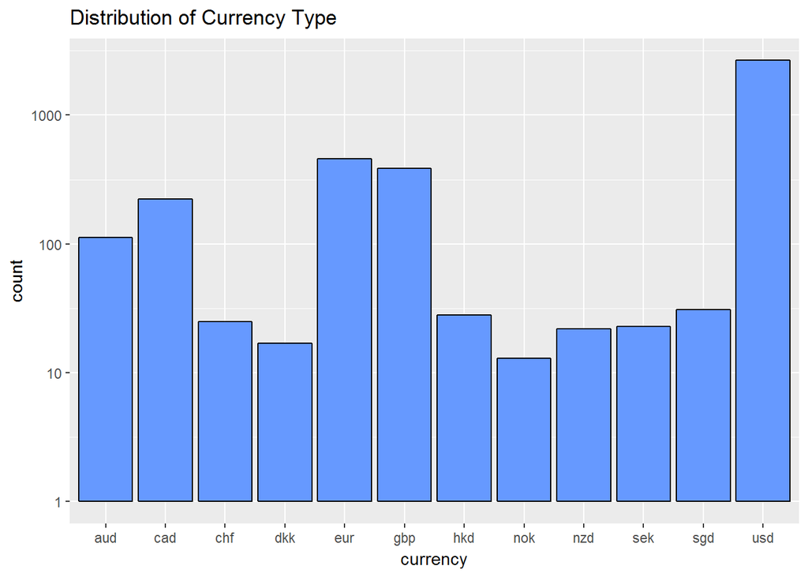

We have a lot of currency option but it looks like Kickstarter is mostly popular with Australia, US, CA, UK, and the EU. In the future, we will only want to use these currencies.

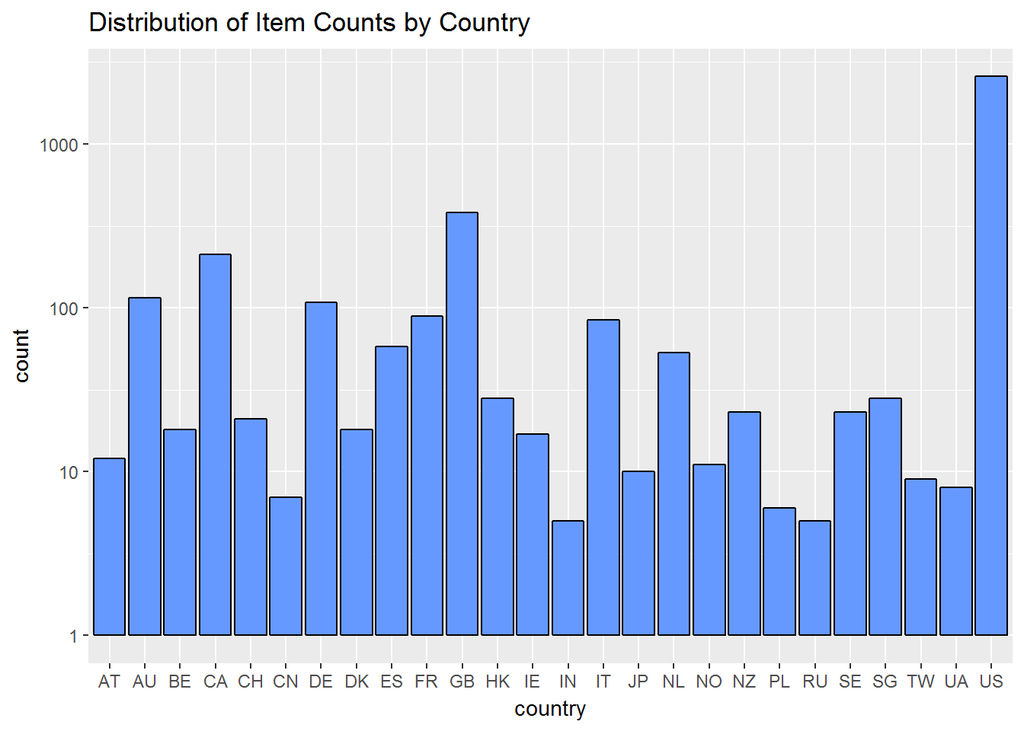

It looks like our currency distributions match up with our items by country. Not much Kickstarter usage in Asian countries.

# Univariate Analysis

### What is the structure of your dataset?

Columns consist of the following types and values

```
## 'data.frame':    4000 obs. of  15 variables:
##  $ amt.pledged      : int  15823 6859 17906 67081 32772 2065 577844 4952 45959 214035 ...
##  $ blurb            : Factor w/ 3998 levels "\n'Catalysts, Explorers & Secret Keepers: Women of Science Fiction' is a take-home exhibit & anthology by the Museum of Science"| __truncated__,..: 1 621 337 3169 3330 1974 2628 3424 319 558 ...
##  $ by               : Factor w/ 3985 levels "#LAUNCHLINASLUNCH   :) <3",..: 2704 3772 3591 1880 369 3349 2987 2235 1981 3435 ...
##  $ country          : Factor w/ 68 levels "AE","AF","AT",..: 65 65 65 65 56 65 65 65 65 65 ...
##  $ currency         : Factor w/ 12 levels "aud","cad","chf",..: 12 12 12 12 2 12 12 12 12 12 ...
##  $ end.time         : Date, format: "2016-11-01" "2016-11-25" ...
##  $ location         : Factor w/ 1364 levels "\\xd6stersund, Sweden",..: 1303 962 690 163 595 762 1338 962 690 690 ...
##  $ percentage.funded: int  186 8 102 191 34 114 5778 42 153 611 ...
##  $ state            : Factor w/ 264 levels "AB","Abruzzi",..: 56 175 29 169 103 67 57 175 29 29 ...
##  $ title            : Factor w/ 3998 levels "- Mermaid Chic - Limited Edition Enamel Pins",..: 670 3573 2310 2391 3489 2866 2520 1641 1402 2469 ...
##  $ type             : Factor w/ 6 levels "County","Island",..: 5 5 5 1 5 5 5 5 5 5 ...
##  $ url              : Factor w/ 3999 levels "/projects/1000225294/color-box?ref=discovery",..: 899 3889 1337 2535 3012 2692 3818 2912 1633 879 ...
##  $ title.length     : int  50 51 26 57 32 19 42 34 38 53 ...
##  $ blurb.length     : int  136 137 119 115 92 120 129 122 127 131 ...
##  $ weeks.until.end  : Factor w/ 9 levels "8","7","6","5",..: 9 5 6 9 6 5 6 5 8 9 ...
```

- amt.pledged is the total amount of funding the project has at that time
- blurb is a text field that describes the project being funded
- by is the field containing the username of the user asking for funding
- country is the user’s country
- currency is the user’s native currency
- end.time is the date the project will be closed for additional funding
- location is string field for the users city, town, state, or really any location text
- percentage.funded is the percentage describing amt pledged / amt needed
- state is the state or province the user is located in
- title is the name of the project being funded
- type is the location type with discrete values, town, island, county, etc
- url is the link to the project on Kickstarter.com
- title.length is a feature I engineered that has the length of the title in terms of character count.
- blurb.length is another engineering feature that has the length of the blurb in terms of character count.
- weeks.until.end is my final engineered feature that is the number of weeks until the project’s funding period has ended. A value of 0 indicates this current week.

### What is/are the main feature(s) of interest in your dataset?

Amount pledged and Percent funded.

### What other features in the dataset do you think will help support your investigation into your feature(s) of interest?

I would like to see if there is any relationship between currency (as a substitue for location), endtime, and our amount pledged and percent funded variables.

### Did you create any new variables from existing variables in the dataset?

I created title and blurb length columns as well as a weeks until end date column.

### Of the features you investigated, were there any unusual distributions? Did you perform any operations on the data to tidy, adjust, or change the form of the data? If so, why did you do this?

- Distribution of Percentage Funded showed right skew
- I used a log10 scale when plotting Amount Pledged as there was very strong right skew
- Distribution of Title length is roughly bimodal with a mode at the title character limit, 60.
- Similar to title length, blurb length’s mode appears to be at the character limit ~137. This plot has left skewness.
- Location type was predominately Town, currency was overwhelmingly USD, and item country was also mostly US. All of these plots’ y-axis have been adjust by log10.

# Bivariate Plots Section

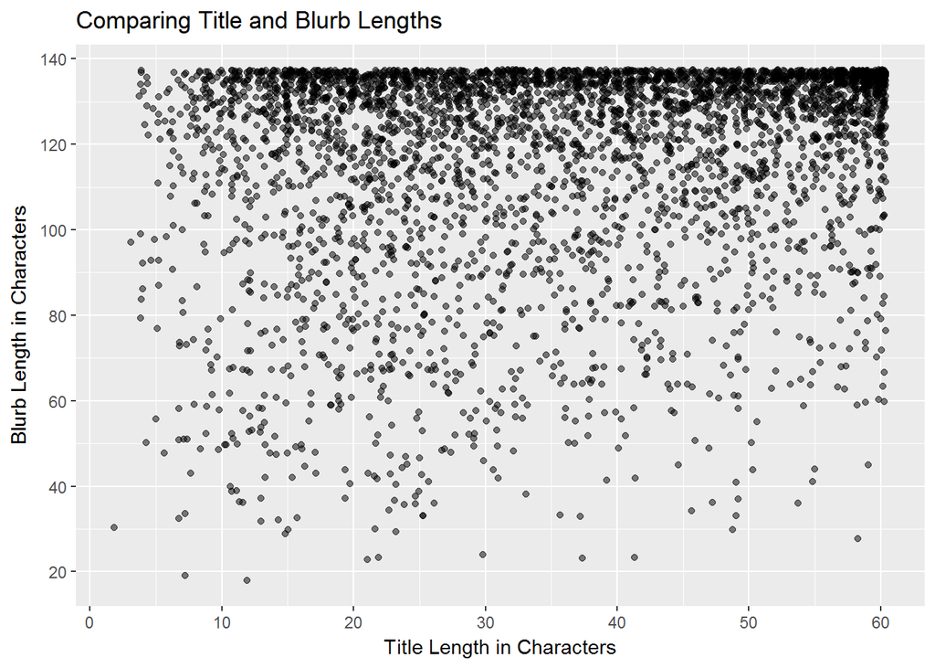

I wanted to visualize our text based columns relationship here, we already saw that users are typically using the whole blurb field but not always the full title space, here we can see that by the density of points at the top of the chart.

In the next few plots you will see me plot our text fields (blurb, title) character lengths against our features of interest (amount pledged, percentage pledged). I was really hoping to see more of a relationship between the variables I created and our features of interest but there does not appear to be much there.

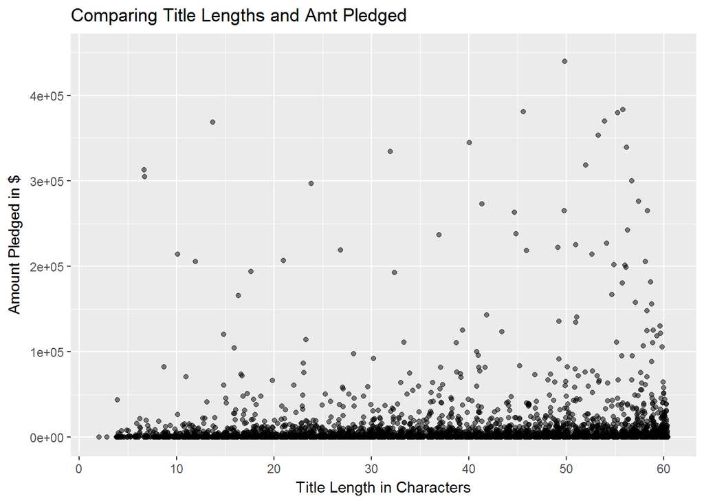

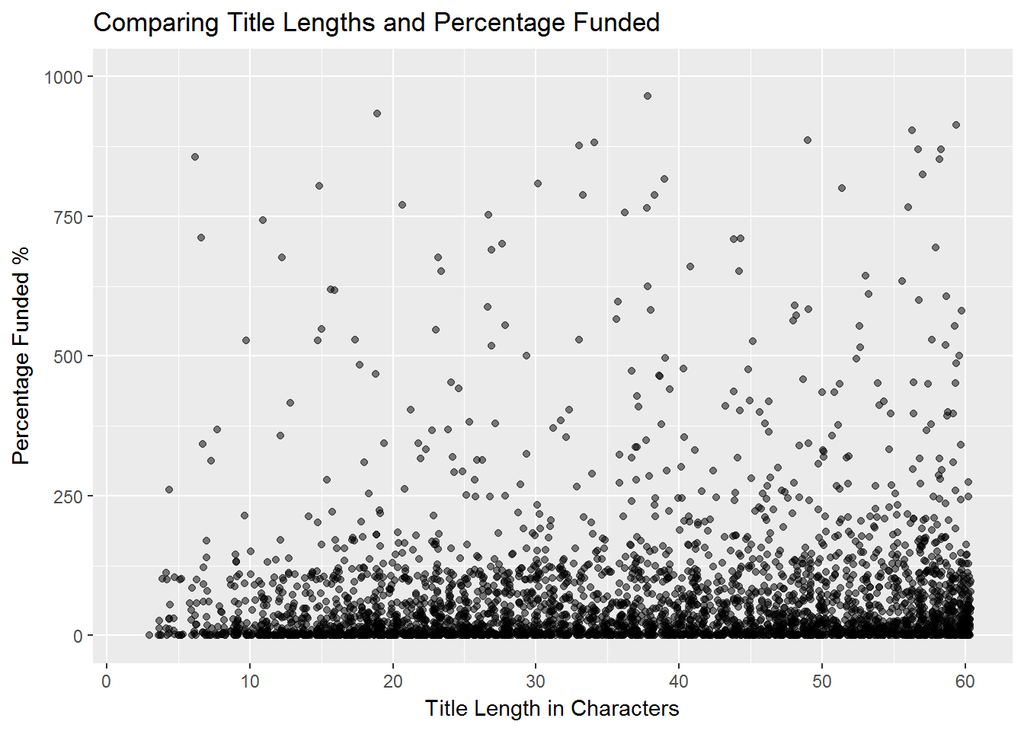

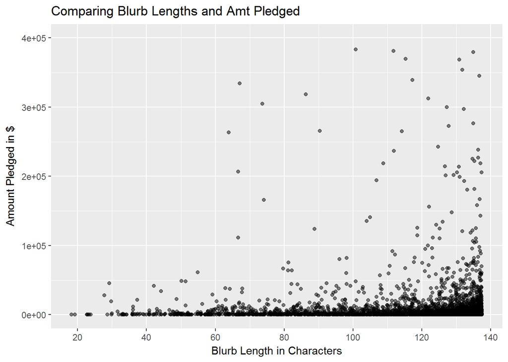

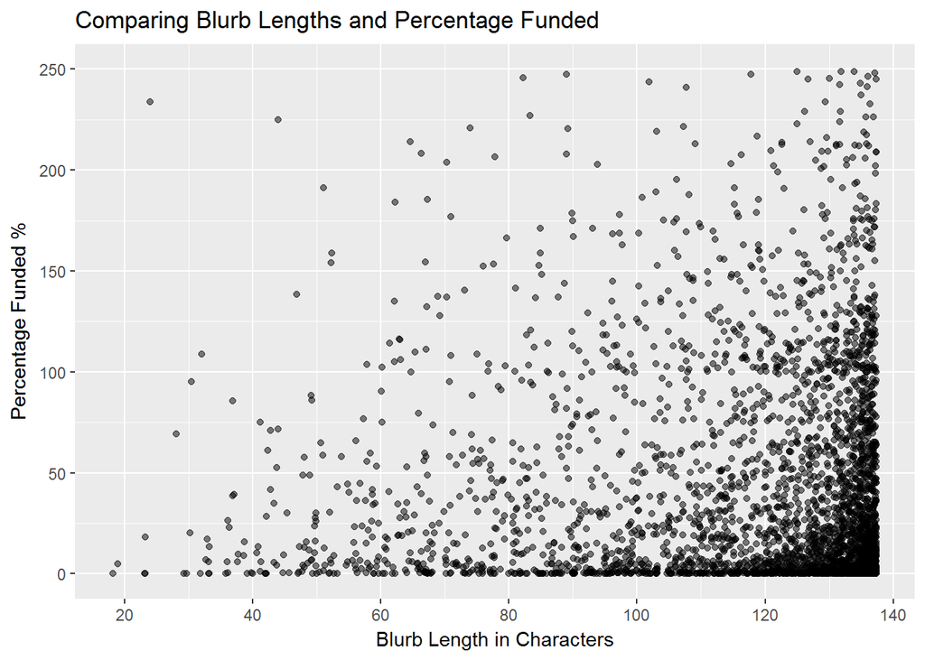

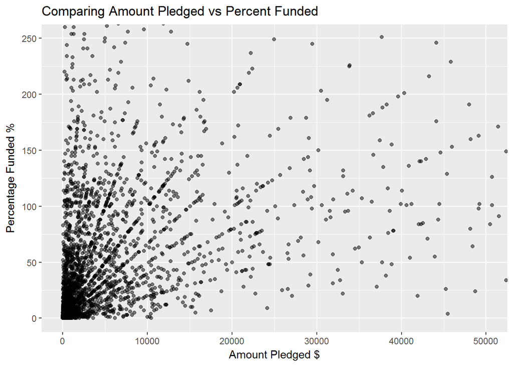

Here we are looking at our 2 features of interest plotted against eachother. It looks like most our projects under 50% funding receive less than $5,000, but several projects need less than $5,000 to even meet their funding goals so we some density following the y-axis up.

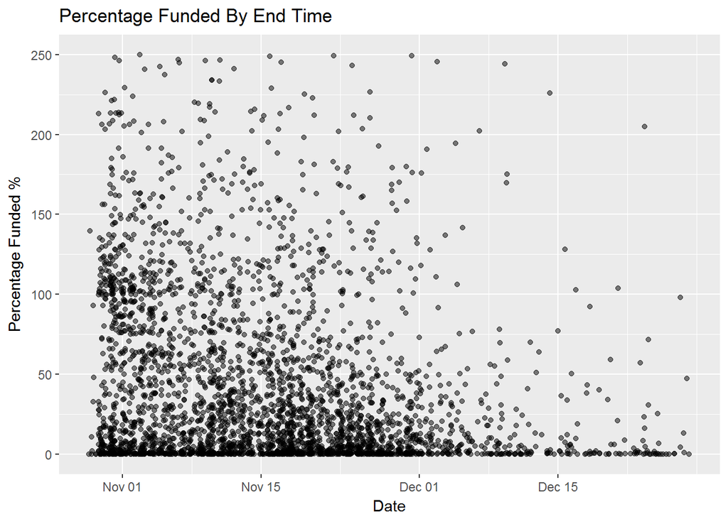

In the plot above I wanted to see the trend between percentage funded and end time. As we can see, projects with later end time have lower percentages of funding as they likely have not been on Kickstarter as long as those with early November end times.

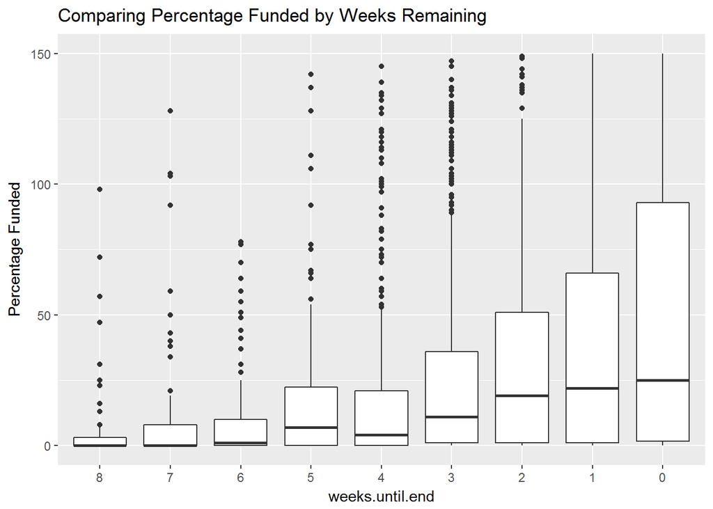

Here is another view of the percentage funded over time but using a box plot and our weeks.until.end variable. As you can see mean percentage funded increases as weeks.until.end decreases. We will dive further into this in our Final Plots section.

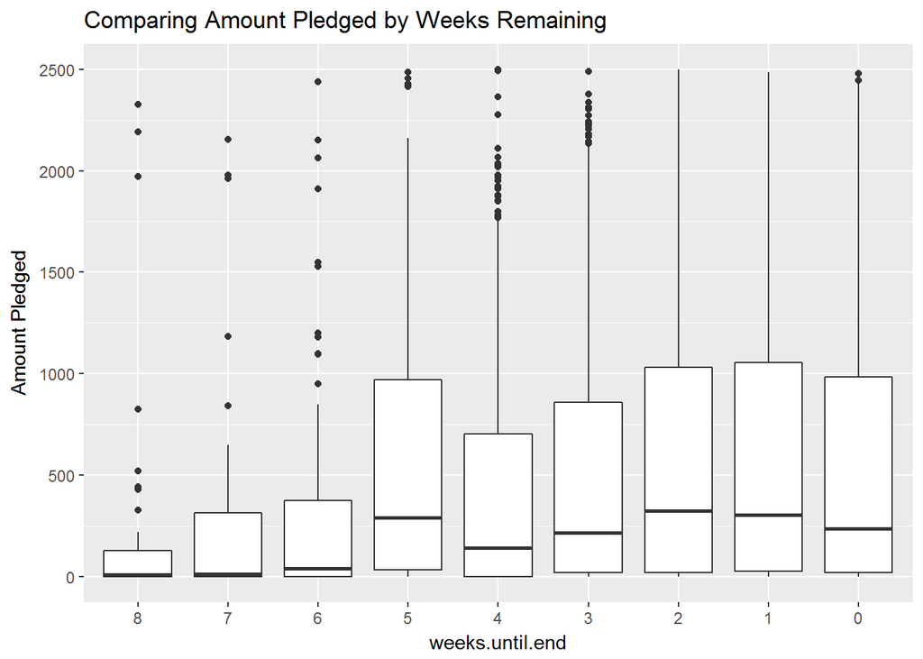

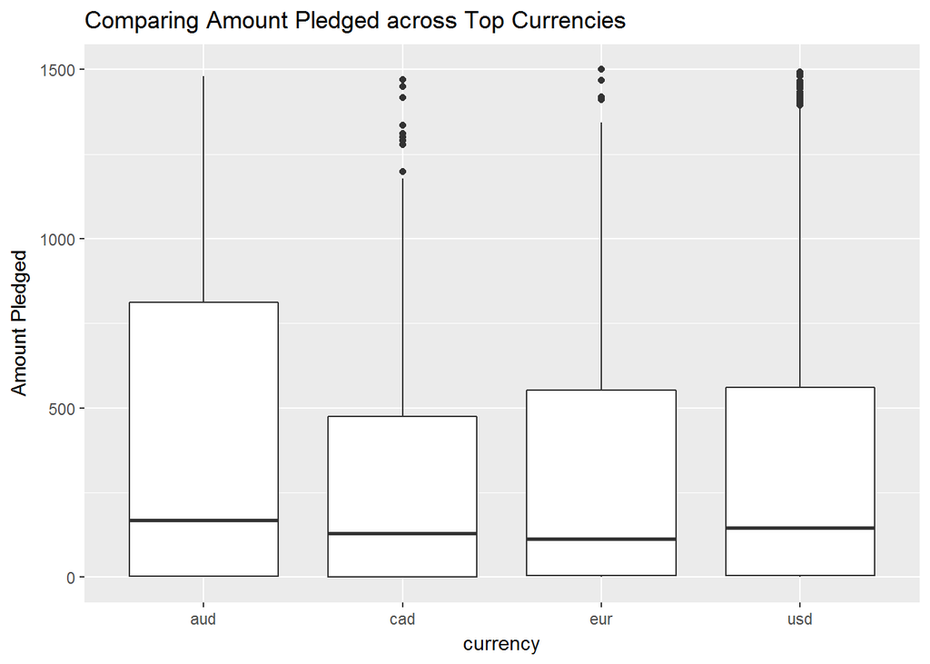

It looks like our mean amount pledged does not vary much between currencies, however we Australian projects seem to have a much larger IQR that our other ‘top currencies’

```
##                   title.length blurb.length percentage.funded amt.pledged
## title.length        1.00000000  0.189534330        0.03991627 0.063074545
## blurb.length        0.18953433  1.000000000       -0.00423001 0.002542503
## percentage.funded   0.03991627 -0.004230010        1.00000000 0.372049603
## amt.pledged         0.06307455  0.002542503        0.37204960 1.000000000
```

# Bivariate Analysis

### Talk about some of the relationships you observed in this part of the investigation. How did the feature(s) of interest vary with other features in the dataset?

There is only one weak correlation in all of our data and that is between Amount Pledged and Percentage Funded. Of course we would expect that the more money pledged to your goal, the closer you are to reaching your funding goals.

Title and blurb length, the variables I created, did not prove to have much influence on funding/percentage funded.

### Did you observe any interesting relationships between the other features (not the main feature(s) of interest)?

Not particularly, I was hoping to find something that might serve as a good predictor for reaching a value of 100 (or greater) in percentage funded, but I do not seem to have any yet.

I may have to revisit this and look for key words in titles and blurbs that might have an association with higher percentage funded scores.

### What was the strongest relationship you found?

As you would expect it was a weak correlation between Amount Pledged and Percentage Funded.

# Multivariate Plots Section

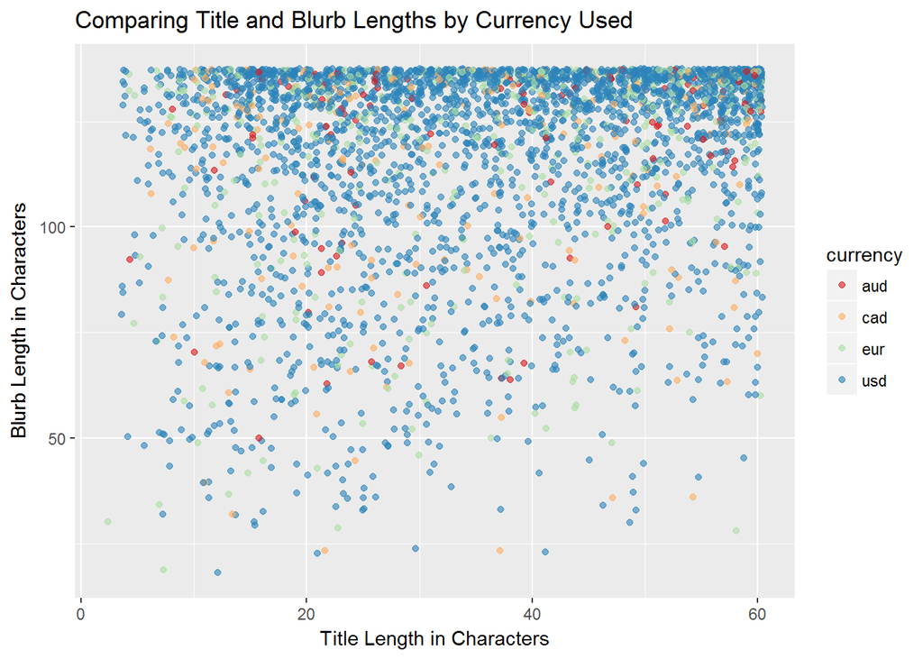

I was looking for clusters here to see if different currencies had a relationship with blurb and title length. I.E. Are users in the European market more brief in their blurb descriptions, etc. But there was nothing to be found aside from a reminder that Kickstarter has a disproportionately large US user base.

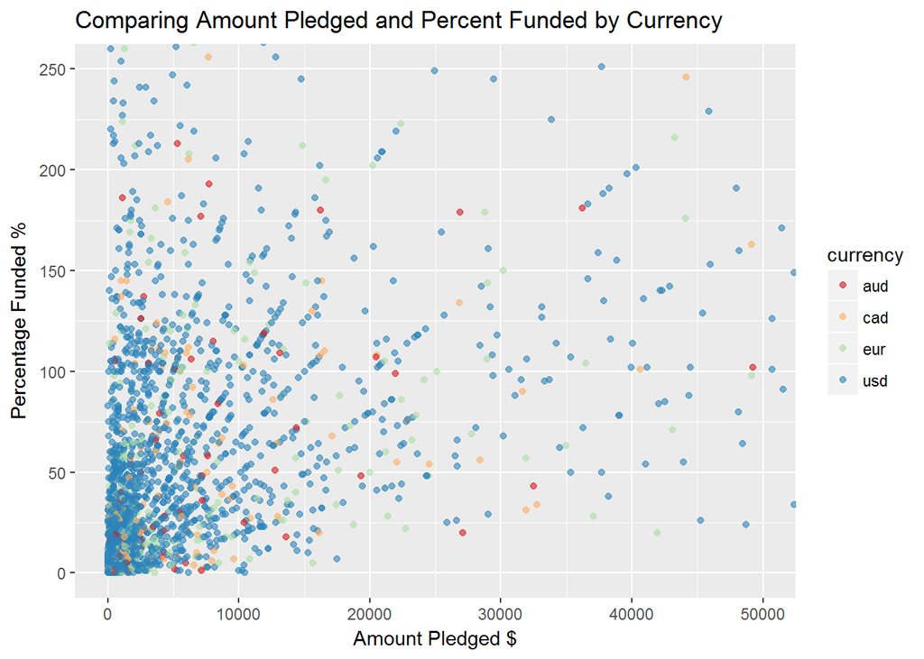

Now I am comparing currency with our main features to look for any relationships; none to be found.

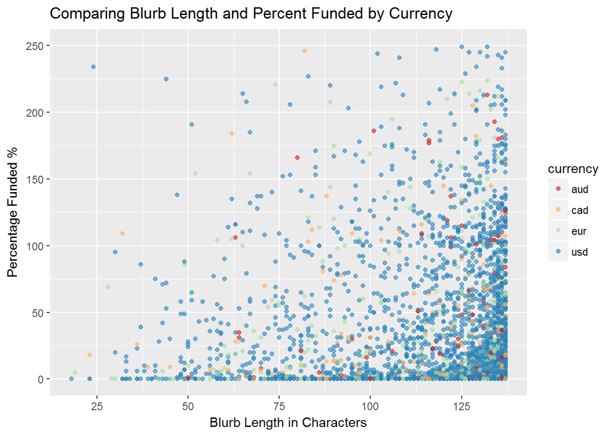

There does not appear to be any relationship between currency and our Blurb vs Percent Funded plot.

[figure not shown]

Again, looking for relationships with currency but I guess we can conclude that users of differenty currency use Kickstarter similarly.

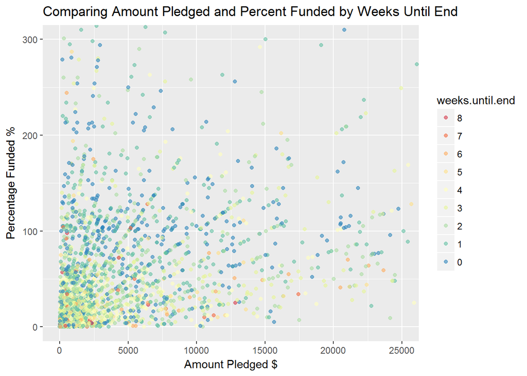

I like this plot, we can clearly see that as you move ‘out’ toward higher funded projects, the end time is closer than our under funded projects. This is really intuitive but it is neat to see visualized.

# Multivariate Analysis

### Talk about some of the relationships you observed in this part of the investigation. Were there features that strengthened each other in terms of looking at your feature(s) of interest?

I was looking for possible relationships between currency and our main features to see if there were any identifiable differences between regions and their investment habits with KickStarter. Currency or country of origin has no discernable relationship with either of our main features in this case.

### Were there any interesting or surprising interactions between features?

I wouldn’t consider it surprising but in the Comparing Amount Pledged and Percent Funded by Weeks Until Endtime, you can see that as you move toward higher values along the x or y axis, points are generally darker, indicating that their funding periods are coming to a close.

To dig further into this question I would have to dive a little deeper into the contents of the blurb or title and look for associations between keywords and amt funded or pledged.

# Final Plots and Summary

### Plot One

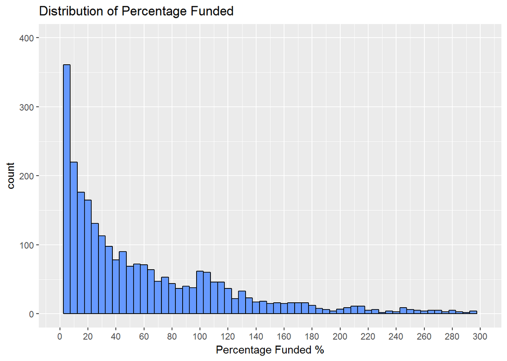

```
##     Min.  1st Qu.   Median     Mean  3rd Qu.     Max.
##     0.00     1.00    18.00    97.16    74.00 28000.00
```

### Description One

Above is the distribution of our projects’ percentage funded. Now, these are all ‘live’ projects meaning they are still open for contributions, but as we can see in the end time distribution plot, most of these projects will end in the 4 weeks.

So, with that being said, we can infer that the median percentage funded for a project on Kickstarter with a month left until end time, is 18% funded.

### Plot Two

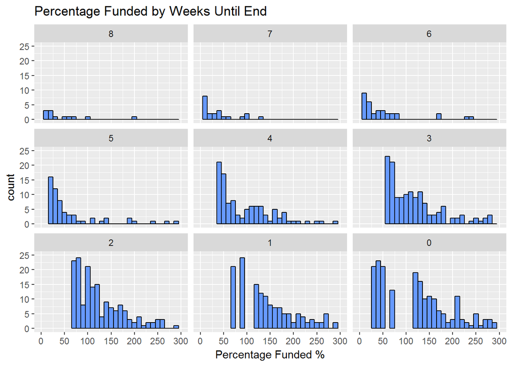

### Description Two

In this plot I decided I would try to show percentage funded by the number of weeks left until the end time. We can clearly see that as weeks until end decreased, we saw a larger amount of our data shift to the right, indicating higher percentage of funding.

### Plot Three

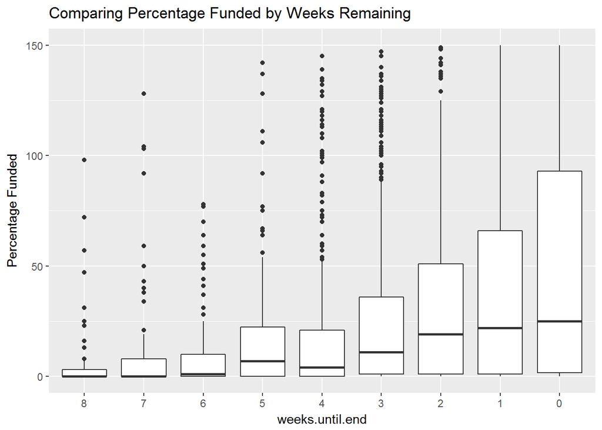

```
##
##  One-way analysis of means (not assuming equal variances)
##
## data:  percentage.funded and weeks.until.end
## F = 13.188, num df = 8.00, denom df = 675.32, p-value < 2.2e-16
```

```
##
##  Pairwise comparisons using t tests with pooled SD
##
## data:  ks$percentage.funded and ks$weeks.until.end
##
##   8      7      6      5      4      3      2      1
## 7 0.6682 -      -      -      -      -      -      -
## 6 0.8103 0.8116 -      -      -      -      -      -
## 5 0.6794 0.9223 0.8514 -      -      -      -      -
## 4 0.6471 0.9164 0.8243 0.9956 -      -      -      -
## 3 0.6266 0.9342 0.7976 0.9663 0.9555 -      -      -
## 2 0.1337 0.3120 0.1151 0.0903 0.0100 0.0056 -      -
## 1 0.2186 0.4711 0.2207 0.2099 0.0576 0.0428 0.4666 -
## 0 0.2822 0.5793 0.3064 0.3169 0.1318 0.1112 0.2570 0.6817
##
## P value adjustment method: none
```

### Description Three

For plot 3 I wanted to visualize project funding in relation to how soon the project ends.

To accomplish this we first plotted the percentage funded against weeks.until.end in a boxplot.

After noticing that mean percentage funded appeared to increase as our weeks.until.end decreased, we performed an ANOVA one way test to see if the mean percentage funded was equal across our different weeks.until.end values.

As expected it was not. The p-value was significant at the 0.05 level (in fact it was 2.2e-16).

Since our means were not equal across our weeks remaining, we used a pairwise T test to find out which means had a statistically significant difference at the alpha = 0.05 level.

From the results in our pairwise comparison table, we can see that Week 2 has a statistically different mean from weeks 3 and 4 and Week 1 with Week 3; suggesting that there is an inverse relationship between percentage funded and weeks.until.end.

# Reflection

Overall this was a fun project, I feel like I have some insight in the world of Kickstarter now.

### Successes and Failures

Successes, I was able to get a sense on * the nationality of the Kickstarter userbase * how long projects typically last * % of projects that meet their funding goals * Amounts pledged to a project

Failures, I was not able to * Determine the types of products on kickstarter * Find any strong correlation between our variables and meeting funding goals * Find differences in user usage of Kickstarter by currency

### How we can improve

Something I left out of our exploration was that I sorted our percentage funded column descending and took a look at some of the most ‘successful’ products by this measure; most of these were either games or books of some variety.

I would like to be able to create a classifier that could examine the text contents in a title or blurb and determine the ‘item type’. Possible item types from my quick glance would be ‘book’, ‘board game’, ‘card game’, ‘fashion accessory’, ‘technology product’, etc.